# An Analysis of the evolution of the Covid-19 pandemic

The high death rate compared to cases in Africa is also reflected in Africa’s vaccine-draught. This is reflected in Figure 4. Africa had significantly less vaccinated individuals than all other continents. This may explain why there is such a large decline in COVID-19 related deaths in Europe, North-America and Asia, as compared to the relatively stable death rate of Africa.

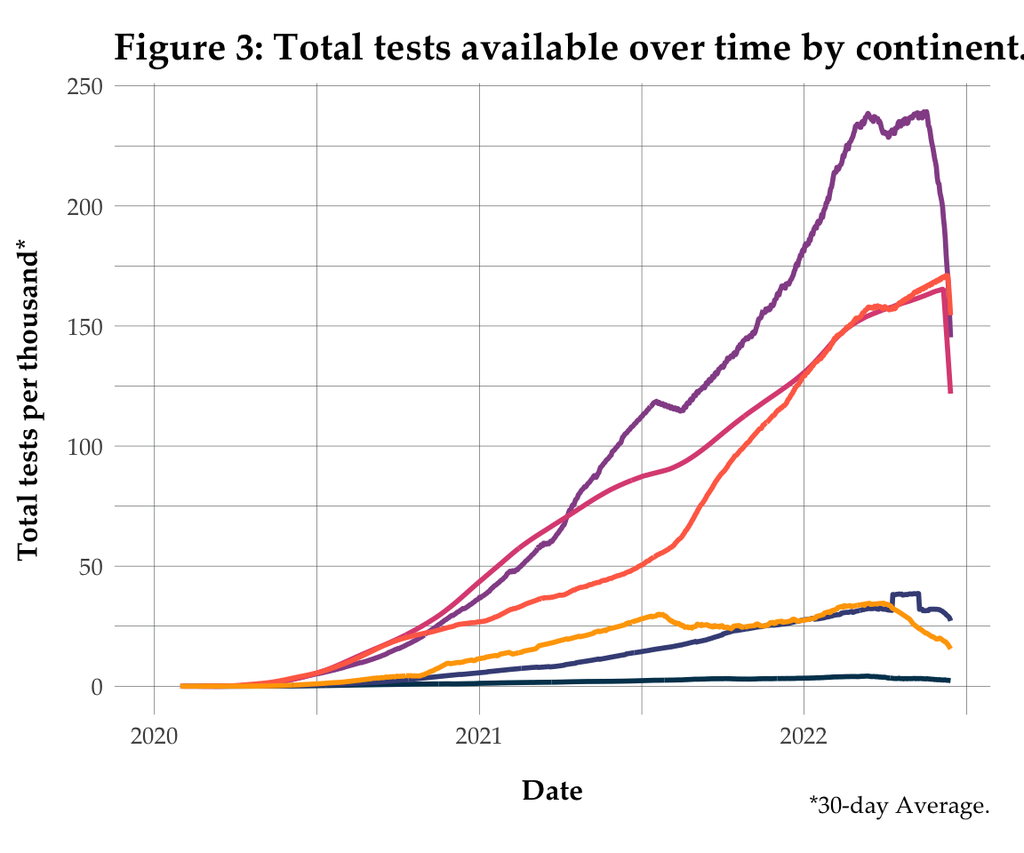

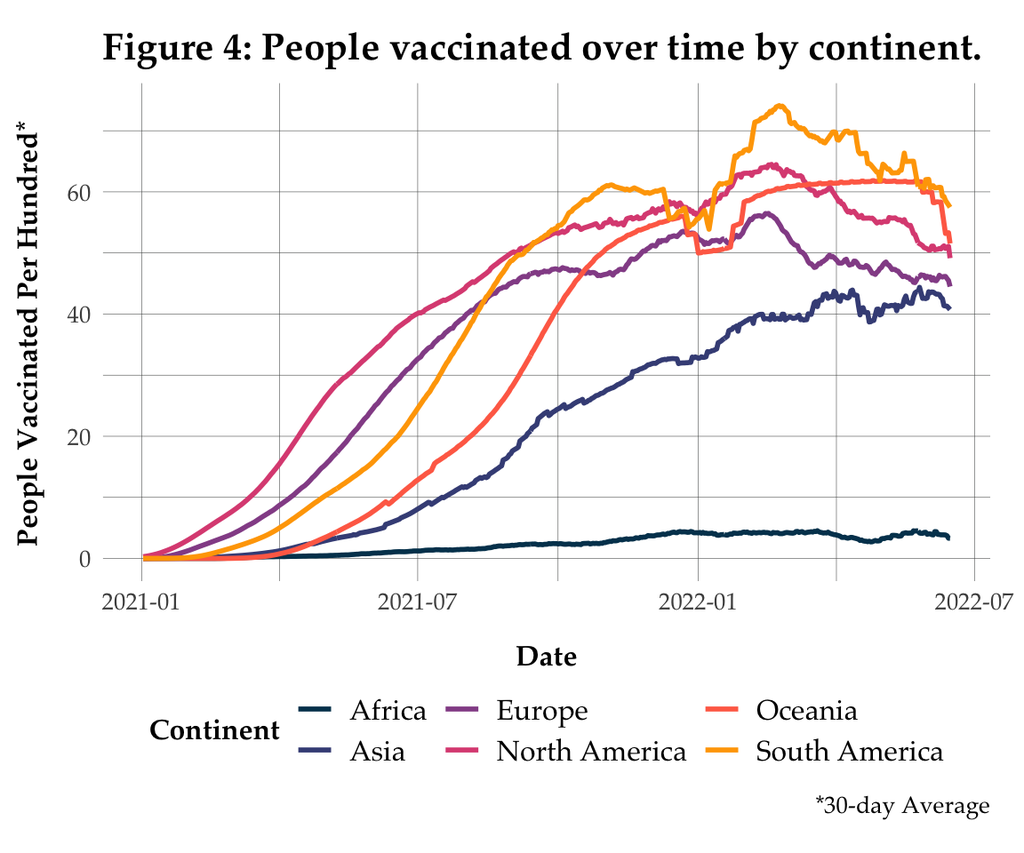

Figure 5 presents a geo-spatial analysis of number of vaccinated individuals and deaths related to COVID-19. The two panels reflect a clear difference in death rates for those countries who successfully increased total vaccinations.

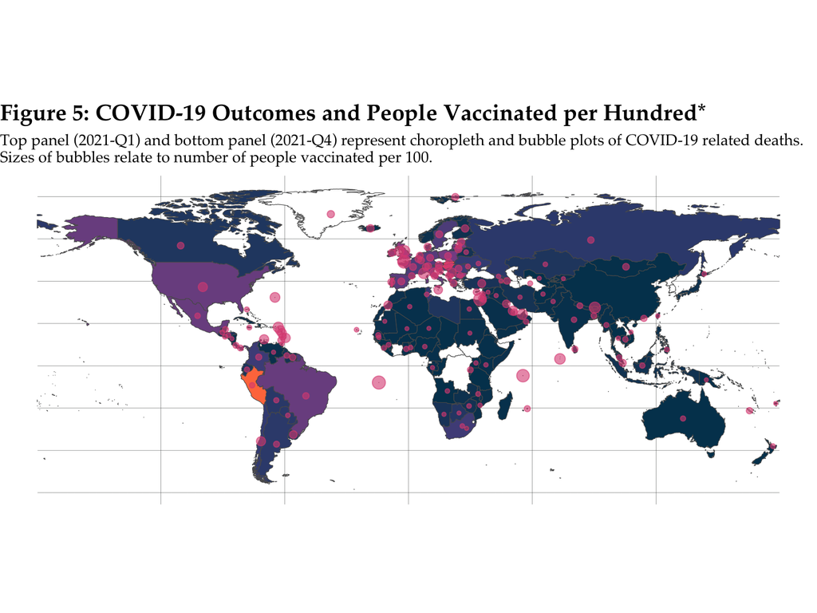

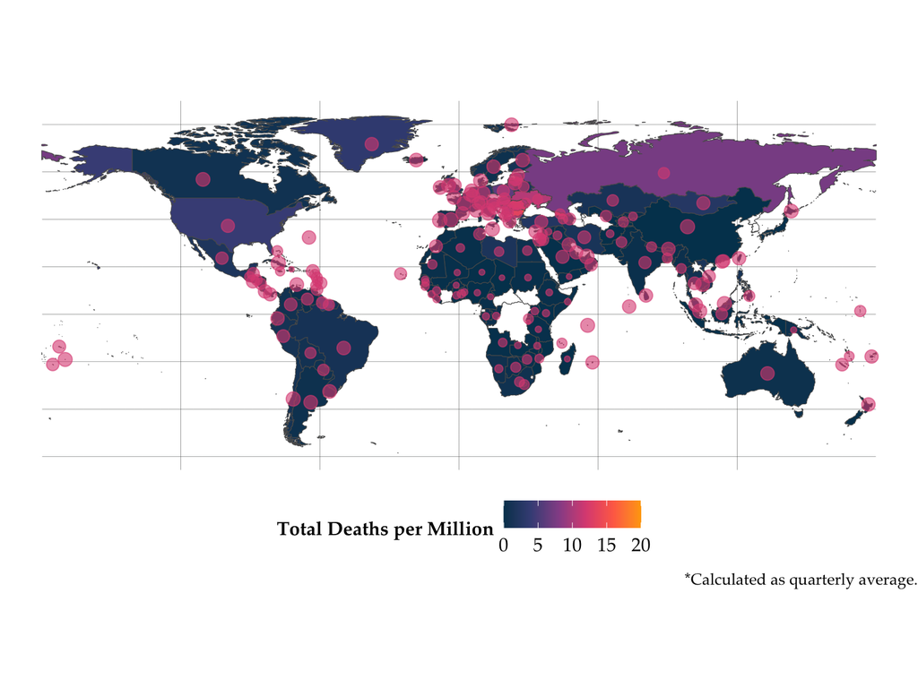